# Multiple Defaults Search Output

# mlr.classif.svm

All plots indicate results from the learner mlr.classif.svm.

**Current status: 49.5 % of results finished.**

### Caveats

- I could create the same plots for Accuracy, and F1 without any big additional effort if required.
- The current analysis contains 36 / 38 datasets for which we have data from the randomBot. I left out two datasets, because they take really long to evaluate (because they are very big).
- The general process of selecting a best configuration using nested CV seems to be decently unstable, at least in the decision trees, we sometimes get worse by selecting a bigger subset of the learned defaults. This is an interesting resarch subject in itself, but might influence our analysis.

## Average rank

The following table contains the average rank, mean auc, normalized mean auc and median of auc across n = 36 hold-out datasets. All results have been obtained using 10-fold CV splits from OpenML and 5-fold nested CV for selecting a configuration in the multiple defaults and random-search case.

```
## # A tibble: 12 x 8
## # Groups:   search.type [?]
##    search.type      n mean_rank_auc mean_auc mn_auc_norm. median_auc   cnt
##    <chr>        <dbl>         <dbl>    <dbl>        <dbl>      <dbl> <int>
##  1 design           1          3.03    0.869      NaN          0.898    36
##  2 design           2          2.42    0.888      NaN          0.928    33
##  3 design           4          2.68    0.876      NaN          0.892    22
##  4 design           6          2.82    0.869        0.737      0.892    17
##  5 design           8          2.33    0.910      NaN          0.925    18
##  6 design          10          2.68    0.876      NaN          0.885    19
##  7 package-def…     1          3.44    0.860      NaN          0.907    36
##  8 random           4          5.4     0.920        0.350      0.958    10
##  9 random           8          5.4     0.918        0.669      0.907     5
## 10 random          16          4.33    0.927        0.737      0.917     6
## 11 random          32          3.6     0.938        0.838      0.964     5
## 12 random          64          2.71    0.909        0.869      0.916     7
## # ... with 1 more variable: cnt_na <int>
```

## Comparison to randomSearch

Boxplot of n found defaults (design) vs. package defaults and random search with design.

**Left** Boxplot of performances using n = 2, 4, 6, 8, 10 complementary defaults

**Mid** Package Defaults

**Right** Randomsearch with n = 4, 8, 16, 32, 64 configurations randomly drawn from the parameter space.

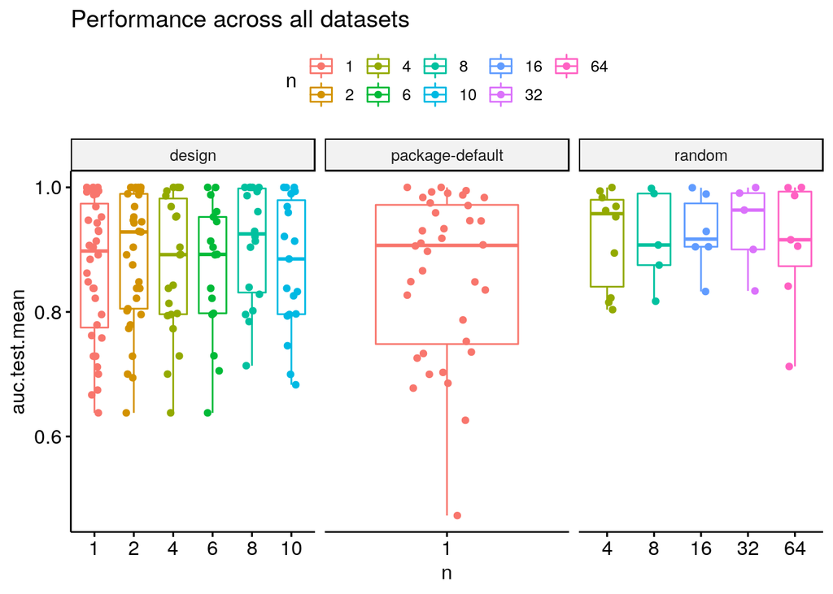

## Comparison to n-fold randomSearch

Boxplot of n (2, 4, 8) found defaults (design) vs. random search with $n \cdot 1,2,4,8$ times random search. Values $> 0$ indicate an improvement of randomsearch using multiples of n over obtained defaults.

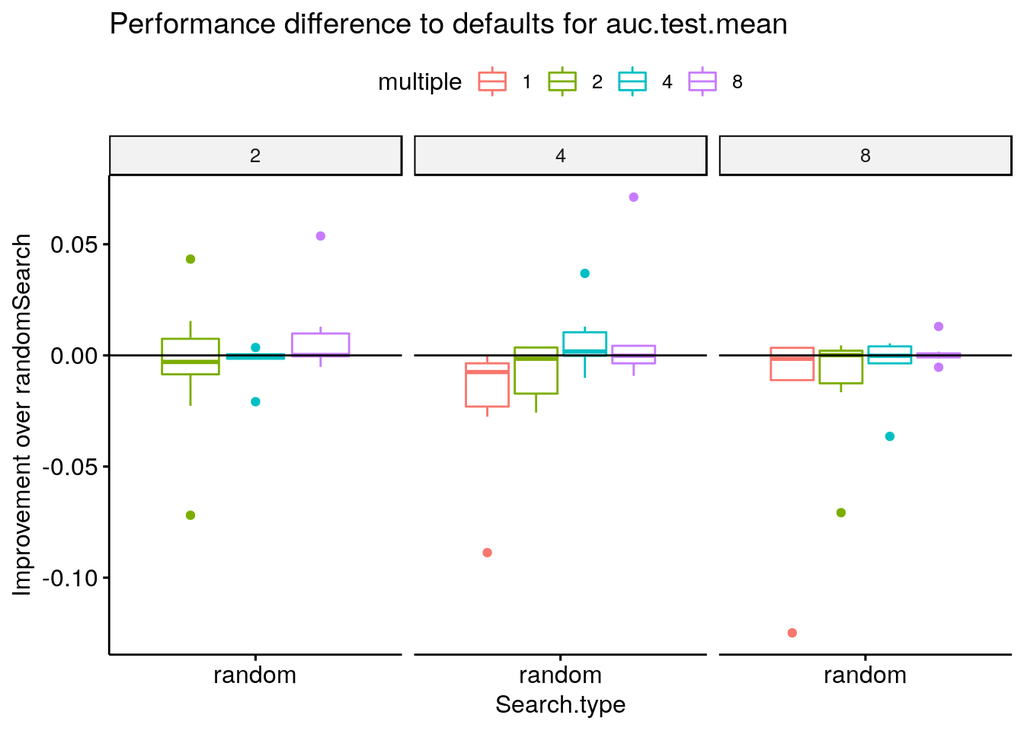

## Comparison to randomBotdata

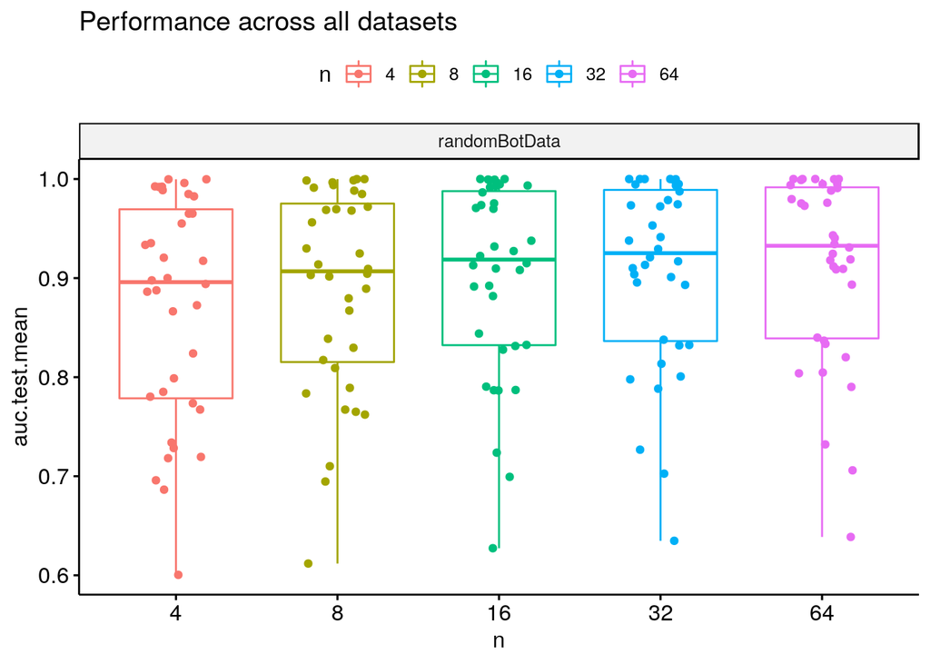

## Delta comparison to package defaults

This plot indicates the difference to package defaults measured in AUC. Values larger than 0 indicate improvement over package defaults.

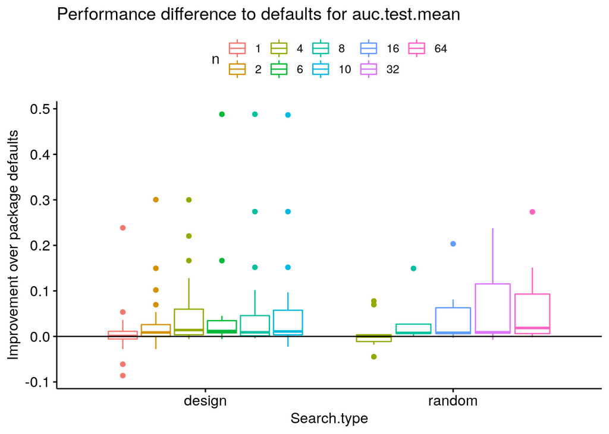

## Plotting the ranks

Plot containing the ranks of the different elements of the first table

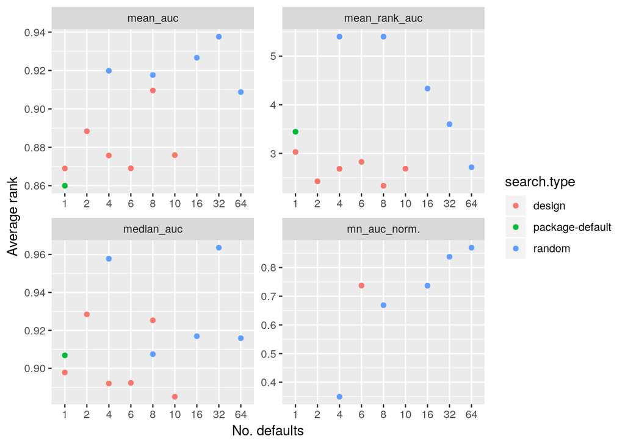

## Comparing different Aggregation functions:

**design**: Aggregate using the median

**default_mean**: Aggregate using the mean

**default_cycle**: Aggregate cycling through the quantiles (0.7, 0.3 and 0.5)

**hodges-lehmann**: Aggregate using the hodges-lehmann criterion (0.33 max() + 0.66 mean()).

If the following table does not contain differnt **search.types**, this indicates that results have not yet been computed for this learner.

*mn_auc_norm.* is short for mean_auc_normalized (normalized to [0, 1]).

```
##   search.type  n mean_rank_auc  mean_auc mn_auc_norm. median_auc cnt
## 1      design  1      3.027778 0.8690109          NaN  0.8978034  36
## 2      design  2      2.424242 0.8883710          NaN  0.9284205  33
## 3      design  4      2.681818 0.8757296          NaN  0.8920338  22
## 4      design  6      2.823529 0.8690824    0.7371139  0.8923594  17
## 5      design  8      2.333333 0.9096049          NaN  0.9252893  18
## 6      design 10      2.684211 0.8759335          NaN  0.8850618  19
##   cnt_na
## 1      0
## 2      0
## 3      0
## 4      0
## 5      0
## 6      0
```

### Overall means for different search.types

```
## # A tibble: 1 x 5
##   search.type mean_rank_auc mean_auc mean_auc_norm. mean_med_auc
##   <chr>               <dbl>    <dbl>          <dbl>        <dbl>
## 1 design               2.66    0.881            NaN        0.903
```

### Overall means for different n

```
## # A tibble: 6 x 5
##       n mean_rank_auc mean_auc mean_auc_norm. mean_med_auc
##   <dbl>         <dbl>    <dbl>          <dbl>        <dbl>
## 1     1          3.03    0.869        NaN            0.898
## 2     2          2.42    0.888        NaN            0.928
## 3     4          2.68    0.876        NaN            0.892
## 4     6          2.82    0.869          0.737        0.892
## 5     8          2.33    0.910        NaN            0.925
## 6    10          2.68    0.876        NaN            0.885
```

## TSNE Plot

Plot breaking down the parameter space to two dimensions using TSNE. The different iters refer to different Leave-One-Out Splits of the dataset.

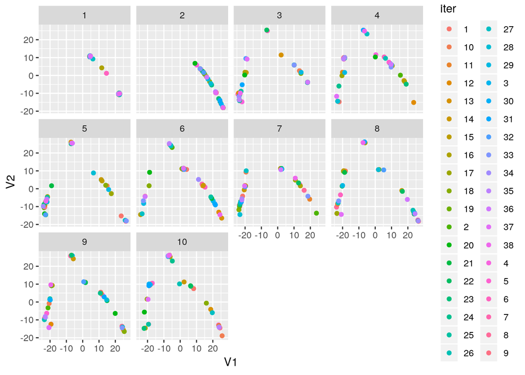